# Project: Investigate a Dataset - [TMDb movie data]

### Question 5 (Which genres are most popular from year to year?)

```python
#we split generes columns and put splited values in a new rows using
#  split function and explode function.
df['genres'] = df['genres'].str.split("|")
df = df.explode('genres')
df.head()
```

[output not shown]

```python
# We get genre of movie that has higher popularity in each year
#    and his summation of popularity in the same year
s = df.groupby(['release_year', 'genres'])['popularity'].sum()
out = s.loc[s.groupby(level=0).idxmax()]
out
```

```
release_year  genres
1960          Drama          7.361967
1961          Drama          6.915731
1962          Drama          7.636277
1963          Thriller       7.199292
1964          Comedy         7.859657
1965          Drama          6.100986
1966          Drama          5.272672
1967          Drama          8.183477
1968          Drama          7.500178
1969          Drama          6.368528
1970          Drama          6.015169
1971          Drama         12.093149
1972          Drama         11.127861
1973          Drama         14.752277
```

[output cut: 43 more lines]

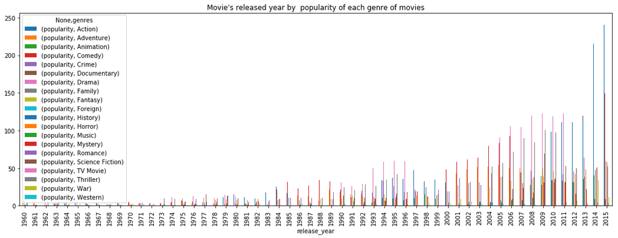

```python
# We use bar chart between release_year and popularity to show us
#  popularity of each genre of movies in each year
q = df.groupby(['release_year', 'genres']).aggregate({"popularity":"sum"})
qq=q.pivot_table(index="release_year", columns="genres", values=["popularity"])
qq.plot.bar(figsize=(18,6))
plt.title('Movie\'s released year by  popularity of each genre of movies')
plt.show()
```

[figure not shown]

```python
# This bar chart shows us just last 5 years

plt.figure(figsize=(25,15))
qq[-5:].plot.bar(figsize=(18,6),title='Movie\'s released year by  popularity of each genre of movies')
plt.show()
```

```python
#As shown above we get in each year which genres is most popular.
```

### Question 6 (Which genre are most popular in dataset?)

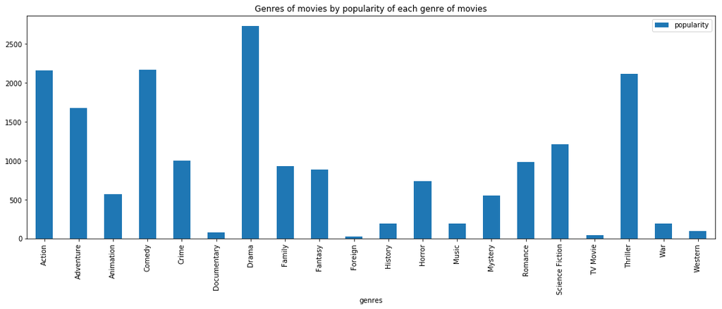

```python
# We get the popularity of each genres in dataset using groupby
#  then plot that data using bar plot.
genre_popularity = df.groupby(['genres']).aggregate({"popularity":"sum"})
tab_genre_popularity = genre_popularity.pivot_table(index="genres", values=["popularity"])
tab_genre_popularity.plot.bar(figsize=(18,6))
plt.title('Genres of movies by popularity of each genre of movies')
plt.show()
```

```python
# As shown above in bar plot, Drama is the genre that has most popularity
```

## Conclusions

> We removed the columns that we don't need in analysis.

> We removed the null values from rows, we found that rows that have null values is not very much so we romoved them.

> We removed duplicated rows, there is just one row is duplicated.

> After we cleaned data we started on exploratory the data and answaring questions.

> **Fist**: We found that movie that has high revenue has high popularity.

> **second**: We found that the movie that achieves high revenues also achieves a high rating, but not at a high rate.

> **Third**: We found that the movie that has a high budget also has a high revenue.

> **Fifth**: we get in each year which genres is most popular.

> **Sixthly**: We found that Drama movies has the most popularity.

> **Limitation of Dataset** 1- Some variables of dataset included a great deal of null data that may result in misleading insights when analyzing, such that homepage column so i opted to delete. 2- I removed some columns that i'w not use them in analysis, such that id, imdb_id, cast, director, tagline, keywords and overview. 3- Budget and revenue columns have many zeros value.

```python
from subprocess import call
call(['python', '-m', 'nbconvert', 'Investigate_a_Dataset.ipynb'])
```

```
0
```